# **Análise da Conservação da Biodiversidade pelo Manejo de Espécies Ameaçadas de Extinção**

Vanessa Silva

19/01/2022

## **1. Descrição geral do problema**

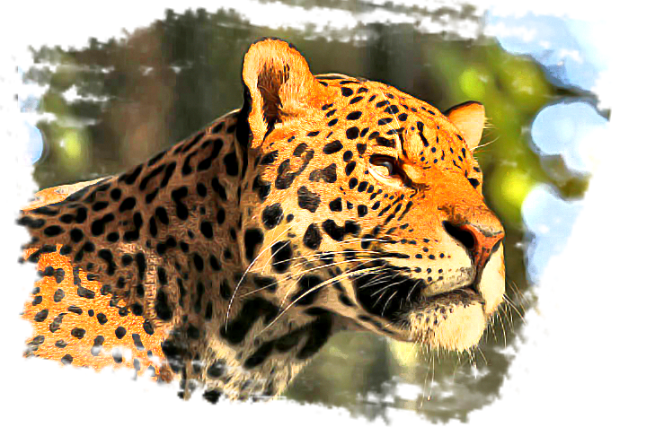

O Brasil é um país de **proporções continentais** que ocupa quase metade da América do Sul e inclui várias zonas climáticas. Essa variedade de clima resultou em mudanças ecológicas dramáticas que criaram biomas únicos como, a **Floresta Amazônica**, o **Pantanal**, o **Cerrado**, a **Caatinga**, os campos dos **Pampas**, e a floresta tropical pluvial da **Mata Atlântica**, além da vasta costa oceânica que inclui ecossistemas como recifes de corais, dunas, manguezais, lagoas, estuários e pântanos. Dois desses biomas, o Cerrado e a Mata Atlântica, são áreas de grande riqueza e endemismo e consideradas uma prioridade global de conservação

A biodiversidade fornece os *“serviços ambientais”* para os seres humanos, a partir dessa conservação e funcionamento dessas interações, a sociedade obtém os **suprimentos**, **energia** e outros produtos e serviços que contribuem para o *desenvolvimento econômico* e *social* do planeta. Entretanto, o funcionamento dos biomas, convive com a evolução e as transformações no planeta, que ameaçam o seu funcionamento e a sua existência. Somente após 1967 o problema da perda de biodiversidade despontou dentre os temas ambientais planetários, juntamente com outros temas ambientais.

As **alterações no ambiente** afetam **gravemente** a biodiversidade. Estes danos são causados pela exploração predatória para abertura de novas áreas, degradação do meio ambiente, catástrofes naturais, incêndios florestais, bem como a extração desordenada, a poluição entre uma série de outros fatores que poderão interferir de forma direta ou indireta. Este fato é observado em todos os biomas brasileiros.

A **compreensão** do estado de **conservação** da biodiversidade é o ponto de partida para o planejamento sistemático das **medidas** que devem ser tomadas para **reduzir** o *risco* de **extinção das espécies**, garantir sua sobrevivência e, assim, manter o funcionamento do ecossistema.

[figure not shown]

## **2. Carregando Dados**

### **2.1 Importando bibliotecas necessárias**

Começaremos nosso projeto, importanto todas as bilbiotecas necessárias para o processamento dos dados.

### **2.2 Carregando Dados**

Fonte: [Portal de Dados Abertos MMA](http://dados.mma.gov.br/dataset/41a79b71-445f-4a6a-8c70-d46af991292a/resource/1f13b062-f3f6-4198-a4c5-3581548bebec/download/lista-de-especies-ameacas-2020.csv)

```r
# Carregando conjunto de dados.
df <- read_delim("arquivos/lista-de-especies-ameacas-2020.csv")
#, header = T, sep = ";", fileEncoding = "utf-8"
```

```r
# Exibindo as primeiras linhas e algumas colunas do Dataset.
kable(head(df[,c(1:4,8,9,15)]))
```

| Fauna/Flora | Grupo | Família | Espécie (Simplificado) | Bioma | Principais Ameaças | Estados de Ocorrência |
| --- | --- | --- | --- | --- | --- | --- |
| Flora | Angiospermas | Salicaceae | Abatia angeliana | Mata Atlântica | Perda de Habitat/Degradação (Induzida por Humanos) | PR |
| Fauna | Aves | Cracidae | Aburria jacutinga | Cerrado; Mata Atlântica | Agropecuária; Assentamento Humano:cidades; Extracao Direta:Caça/Pesca; Extracao Florestal | BA; ES; MG; PR; RJ; RS; SC; SP |
| Flora | Angiospermas | Malvaceae | Abutilon anodoides | Mata Atlântica | Assentamentos Humanos: Cidades | RJ |
| Flora | Angiospermas | Malvaceae | Abutilon nigricans | Mata Atlântica | Perda de Habitat/Degradação (Induzida por Humanos) | SP |
| Flora | Angiospermas | Santalaceae | Acanthosyris paulo-alvinii | Cerrado | Perda de Habitat/Degradação (Induzida por Humanos), Extração de Madeira, Agropecuária | BA |
| Flora | Angiospermas | Myrtaceae | Accara elegans | Cerrado; Mata Atlântica | Mineração, Desenvolvimento e Infraestrutura | MG |

## **3. Preparação, limpeza e transformação dos dados para a construção do dashboard**

Antes de prosseguirmos, é importante destacar a informação que cada variável representa:

| Variável | Descrição |
| --- | --- |
| **Fauna/Flora** | É o conjunto de táxons de plantas e/ou animais; |
| **Grupo** | Classificação geral; |
| **Família** | É constituída por um conjunto de gêneros; |
| **Espécie (Simplificado)** | Nome cientíco da espécie sem o autor; |
| **Nome Comum** | Como a espécie é conhecida popularmente; |
| **Categoria de Ameaça** | Categoria de risco de extinção; |
| **Sigla Categoria de Ameaça** | Abreviação de categoria de ameaça; |
| **Bioma** | Tipo de ecossitema de um espaço geográfico; |
| **Principais Ameaças** | Fatores prejudiciais para as espécies; |
| **Presença em Áreas Protegidas** | Presença ou não em áreas protegidas; |
| **Plano de Ação Nacional para Conservação** | Presença em planos de proteção nacionl; |
| **Ordenamento Pesqueiro** | É o conjunto de normas e ações que permitem administrar a atividade pesqueira; |
| **Nível de Proteção na Estratégia Nacional** | Categorização na urgência da conservação das espécies (0 a 5, sendo 0 a mais urgente); |
| **Espécie exclusiva do Brasil** | Espécies que só podem ser encontradas no Brasil; |
| **Estados de Ocorrência** | Estados onde foi identificado a presença da espécie; |

### **3.1 Visão geral dos dados**

```
## Rows: 3,287
## Columns: 15
## $ `Fauna/Flora`                                   <chr> "Flora", "Fauna", "Flo~
## $ Grupo                                           <chr> "Angiospermas", "Aves"~
## $ Família                                         <chr> "Salicaceae", "Cracida~
## $ `Espécie (Simplificado)`                        <chr> "Abatia angeliana", "A~
## $ `Nome Comum`                                    <chr> "-", "Jacutinga", "-",~
## $ `Categoria de Ameaça`                           <chr> "Vulnerável (VU)", "Em~
## $ `Sigla Categoria de Ameaça`                     <chr> "VU", "EN", "CR", "CR"~
## $ Bioma                                           <chr> "Mata Atlântica", "Cer~
## $ `Principais Ameaças`                            <chr> "Perda de Habitat/Degr~
## $ `Presença em Áreas Protegidas`                  <chr> "Sim", "Sim", "Sim", "~
## $ `Plano de Ação Nacional para Conservação (PAN)` <chr> "Sim", "Não", "Sim", "~
## $ `Ordenamento Pesqueiro `                        <chr> "Não", "Não", "Não", "~
## $ `Nível de Proteção na Estratégia Nacional`      <dbl> 2, 4, 2, 2, 2, 3, 2, 2~
## $ `Espécie exclusiva do Brasil`                   <chr> "Sim", "Não", "Sim", "~
## $ `Estados de Ocorrência`                         <chr> "PR", "BA; ES; MG; PR;~
```

O conjunto de dados possui **15 variáveis** e **3287 observações**

```r
# Renomeando as colunas para facilitar a manipulação dos dados
colnames(df) = c('Grupao', 'Grupo','Familia', 'Especie', 'NomeComum', 'CategoriaAmeaca', 'SiglaCategoria','Bioma', 'PrincipaisAmeacas', 'AreasProtegidas', 'PAN', 'OrdenamentoPesqueiro', 'ProtecaoNacional', 'ExclusivaBrasil', 'EstadosOcorrencia')
```

Verificando valores únicos existente em cada coluna.

[output not shown]

```r
df$Id <- paste(toupper(str_sub(df$Especie,0,2)),toupper(str_sub(df$Especie,-2)),toupper(str_sub(df$Familia,0,2)),sep = "")
```